# 从一句话到一堂好课：小学数学教师零基础 HTML 互动课件教程

更新日期：2026年5月5日

很多数学老师第一次看到互动 HTML 课件时，会同时产生两种感觉：一方面觉得它特别适合课堂，学生能拖一拖、试一试、比一比，抽象的关系立刻变得可见；另一方面又会本能地退后一步，担心“这是不是要学编程”。其实，零基础教师真正要跨过的第一道门槛不是代码，而是把自己的教学经验翻译成清楚的“互动任务”。

如果你明天要讲“认识面积”，最重要的不是先问 AI 写多少行 JavaScript，而是先想清楚：学生要看见什么？要动手做什么？系统要怎样反馈？错误操作要不要允许？课堂上能不能一眼看出学生是否理解？当这些问题清楚了，HTML 只是承载这些想法的一块会回应的数学黑板。

这本教程面向小学数学教师，默认你不会编程，也不要求你成为前端工程师。学完后，你应能完成四件事：第一，从教材题目或教学难点中找出适合互动化的部分；第二，用结构化提示词让 AI 生成可运行的单文件 HTML；第三，用数学教师的眼光验收作品，而不是被炫酷效果牵着走；第四，通过小步迭代把课件改到能在真实课堂使用。

## 第1章 把 HTML 看成一块会回应的数学黑板

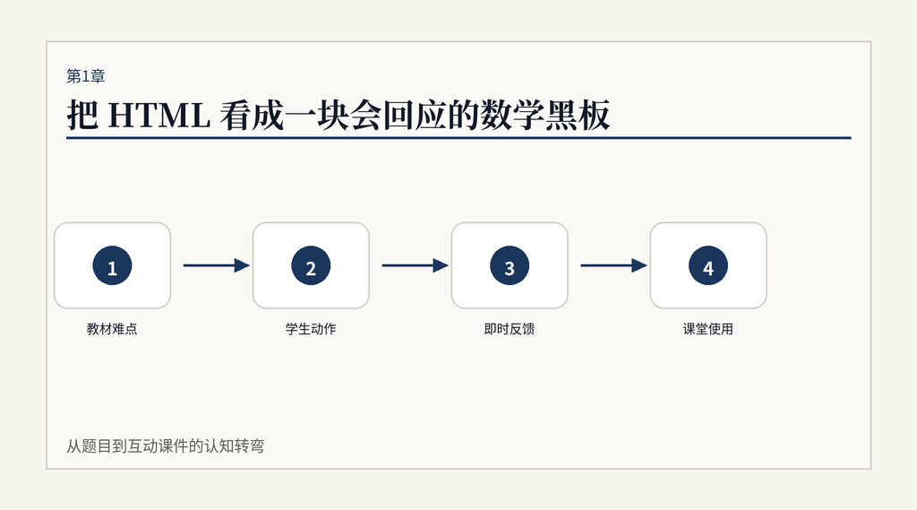

图 1.1

图 1.1：从题目到互动课件的认知转弯

### 1.1 先换一个比喻：不是“写程序”，而是“布置可操作的板书”

本章目标是建立一个轻松但准确的入门心智：HTML 互动课件不是神秘的软件工程，而是一个能显示图形、接收点击拖拽、即时给反馈的课堂页面。传统板书擅长展示过程，PPT 擅长排列内容，而 HTML 擅长让学生参与过程。它可以把一个数轴变成可拖动的数轴，把一个长方形变成能覆盖、能拆分、能比较的面积模型，把一个百数表变成可以筛倍数、找质数、隐藏数字的探索场。

零基础教师最容易犯的错误，是一开口就说“帮我写一个高级课件”。这句话太空，AI 只能猜。更好的起点是像布置板书一样描述页面：中间有什么图形，左边有什么按钮，学生先做哪一步，做完以后看到什么变化。你越能把课堂动作说清楚，生成的 HTML 越接近可用。

> **要注意的地方**：不要把互动理解成“有动画就行”。数学课件的互动，必须让学生的操作改变他们对关系的理解。拖拽、滑块、隐藏、克隆、吸附、比较、统计，都只是手段。

以“有余数除法”为例，普通页面可以显示算式，互动页面则可以让学生把若干个小圆点平均分到几个盒子里，剩下的圆点自动标成“余数”。学生不只是看见结论，而是经历“分不完”的过程。这样的页面不一定华丽，却很有教学价值。

常见误区是把 HTML 当成一次性作品：生成后能打开就算完成。课堂工具更像教具，第一次生成只是毛坯，后面还要调大小、调颜色、调反馈、调错误处理。你的专业价值就在这些调整里。

**本章练习**：从下周要教的一节课中选一个难点，用三句话描述它的互动可能：学生看见什么、能做什么、做完知道什么。检查点：如果把页面关掉，只保留这三句话，别人是否能想象出课堂活动？

### 1.2 判断一个内容是否值得做成互动 HTML

不是所有知识都需要 HTML。适合互动化的内容通常有四类：第一，关系看不清，例如面积、周长、体积、单位进率、圆柱圆锥关系；第二，过程容易被跳过，例如圆面积公式推导、铺地砖数量变化、质数筛选；第三，需要多次试错，例如数对定位、九宫格填数、最短路径、抢数游戏；第四，需要即时统计，例如投票、抢答、生日统计、课堂小测。

判断时可以问一个问题：如果学生能亲手改变一个量，会不会更容易理解另一个量的变化？如果答案是肯定的，HTML 往往值得做。比如“周长一定，谁的面积最大”适合用滑块拖动长和宽；“16 个正方形怎么拼周长最短”适合用拖拽拼摆；“圆的面积公式推导”适合用扇形切分和重组动画。

不适合的情况也要警惕。若学习目标只是记忆概念，做成复杂互动反而分散注意；若课堂时间很短，操作规则太多会喧宾夺主；若学生设备不可控，过度依赖个人操作会增加管理难度。

## 第2章 先写教学剧本，再写提示词

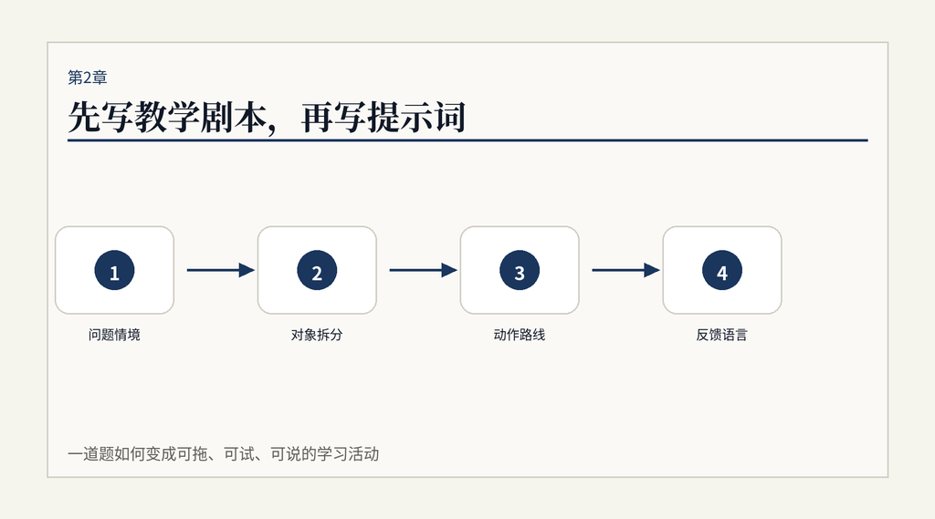

图 2.1

图 2.1：一道题如何变成可拖、可试、可说的学习活动

### 2.1 把教材题目拆成“对象—动作—反馈”

本章目标是学会把一个数学题改写成互动剧本。剧本不是文学创作，而是页面运行说明。最实用的拆法是“对象—动作—反馈”：对象是学生能看见和操作的东西，动作是学生能做的事，反馈是页面告诉学生的结果。

以“铺地砖问题”为例，题目可能给出长 16dm、宽 12dm 的长方形地面，并讨论不同边长的正方形地砖能铺多少块。对象包括长方形地面、正方形地砖网格、边长滑块、数量显示。动作包括拖动滑块改变砖的边长、观察是否整铺、比较块数。反馈包括实时显示横向几块、纵向几块、总块数，以及不能整铺时的提示。

这一步不需要代码，却决定课件质量。若对象少了，页面空泛；若动作太多，学生迷路；若反馈只说“对/错”，数学关系就没有被看见。好的反馈应该把变化说出来，例如“边长变大，每行块数减少，总块数也减少”。

> **要注意的地方**：剧本里的每个动作都要服务学习目标。不要因为按钮好做就加按钮，也不要因为动画好看就加动画。

**本章练习**：选一个“面积一定，谁的周长最短”或“圆内线段直径最长”的问题，列出对象、动作、反馈三栏表。检查点：三栏表中是否至少有一个反馈能解释数学原因，而不只是显示结果？

### 2.2 用“学生会怎样误解”倒推功能

很多高质量课件不是从功能出发，而是从学生误解出发。学生可能把面积当周长，可能认为图形转一转大小会变，可能只看公式不理解为什么余数要小于除数。你要让页面专门暴露这些误解，再给学生修正的机会。

以“认识面积”为例，学生常把“看起来长”误认为“面积大”。页面可以放置两个长方形，一个 2×5，一个 3×4，再提供同样大小的小图形让学生覆盖。学生拖入覆盖后会发现，视觉上细长的图形不一定面积更大。这个过程比直接告诉“面积是面的大小”更有说服力。

这也是提示词前的准备：先写“学生可能误以为……所以页面要让他……”。AI 并不知道你的学生在哪里卡住，只有教师知道。你把误解写进去，页面才会有学科性。

常见误区是把题目截图直接丢给 AI，然后期待它理解课堂。截图能提供形状，却不能提供学生心理。你仍要补上：这节课要突破什么、哪些操作必须允许、哪些错误要被温和地呈现。

## 第3章 五段式提示词工作流

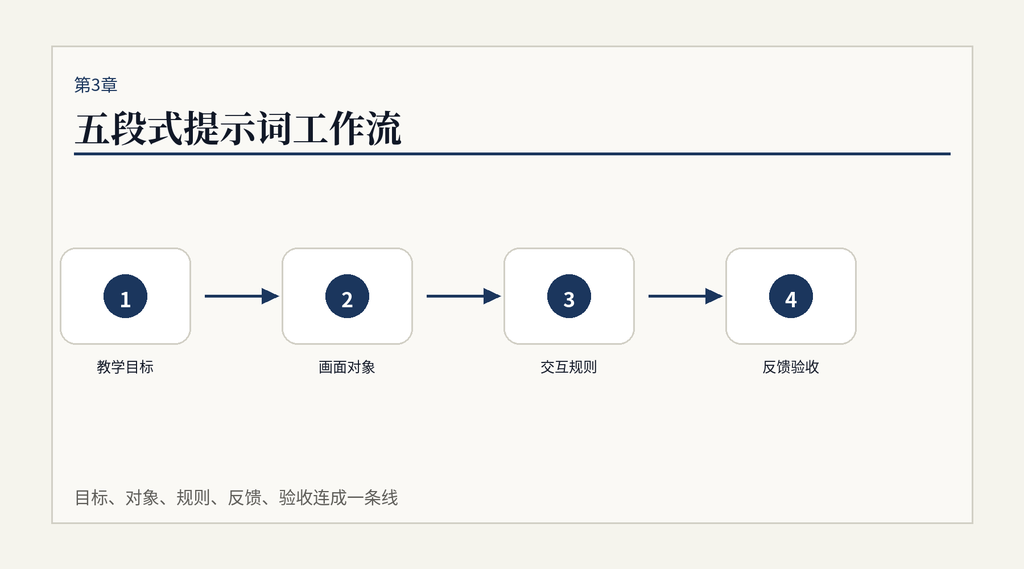

图 3.1

图 3.1：目标、对象、规则、反馈、验收连成一条线

### 3.1 第一段写教学目标：让 AI 知道“为什么做”

本章目标是掌握一套稳定的提示词模板。第一段永远写教学目标，不要先写“做一个漂亮网页”。可以这样写：

> 请制作一个小学三年级数学《认识面积》的单文件 HTML 互动课件。教学目标是让学生通过拖拽覆盖活动，理解面积表示物体表面或封闭图形的大小，并初步感受用统一单位比较面积的必要性。

这段话的价值在于限定方向。AI 会因此知道页面不是游戏娱乐，也不是普通演示，而是要让学生通过覆盖活动形成概念。年级、教材主题、核心理解、活动方式都要尽量出现。

如果你还没有想清目标，可以先用一句朴素话：“学生做完以后能说出……”例如“学生做完以后能说出为什么同样周长围成长方形时，越接近正方形面积越大”。这个句式比抽象术语更适合零基础阶段。

### 3.2 第二段写画面对象：让页面一打开就像课堂

第二段写可见对象。要具体到位置、大小、颜色倾向和文本，但不必写代码。例子如下：

> 页面全屏自适应，背景简洁护眼。上方显示标题和一句任务提示。中间并排放两个可比较的长方形区域，左边为 2×5，右边为 3×4，内部要有淡淡网格。下方放 3 个可拖拽的小图形，大小与网格单位一致。右侧显示当前覆盖数量和观察提示。

这段能显著减少“生成了但不像你想要”的情况。小学数学课件尤其需要明确图形比例，因为比例错了，概念就可能错。比如长方体、圆、钟面、百数表、数轴、方格纸，都不能只说“画一个图”。

> **要注意的地方**：如果涉及教材图形，不要只说“参考图片”。还要把图片中的数学结构说出来，如“长方形长 16、宽 12”“圆柱和圆锥等底等高”“钟面有 12 个大格、60 个小格”。

### 3.3 第三到第五段写规则、反馈和验收

第三段写交互规则：学生能点击什么、拖什么、调什么，边界在哪里，是否支持触摸屏。第四段写反馈：正确时怎样提示，错误时怎样提示，是否实时计算，是否保留操作轨迹。第五段写验收标准：单文件、离线可用、手机和平板适配、按钮足够大、没有多余弹窗、数学结果准确。

一个可复用模板如下：

```
请制作【年级+主题】单文件 HTML 互动课件。
1. 教学目标：学生通过【操作】理解【数学关系】，能用自己的话解释【关键结论】。
2. 画面对象：页面包含【对象A】【对象B】【控制区】【反馈区】，布局为【左/中/右】。
3. 交互规则：学生可以【拖拽/点击/滑动/克隆/隐藏】，操作边界是【限制】，支持鼠标和触摸屏。
4. 反馈机制：页面实时显示【数量/关系/过程】，错误操作提示【温和语言】，关键变化用【颜色/动画/文字】强调。
5. 验收标准：数学结果正确；全屏自适应；按钮不遮挡；单文件可离线打开；代码中不要依赖外部网络资源。
```

常见误区是一次性要求太多：既要三维、又要闯关、又要排行榜、又要语音。零基础阶段先做“一个概念、一个核心动作、一个清楚反馈”。等主线稳定，再加挑战模式、打印模式、随机出题等扩展。

## 第4章 第一个作品：百数表与认识面积

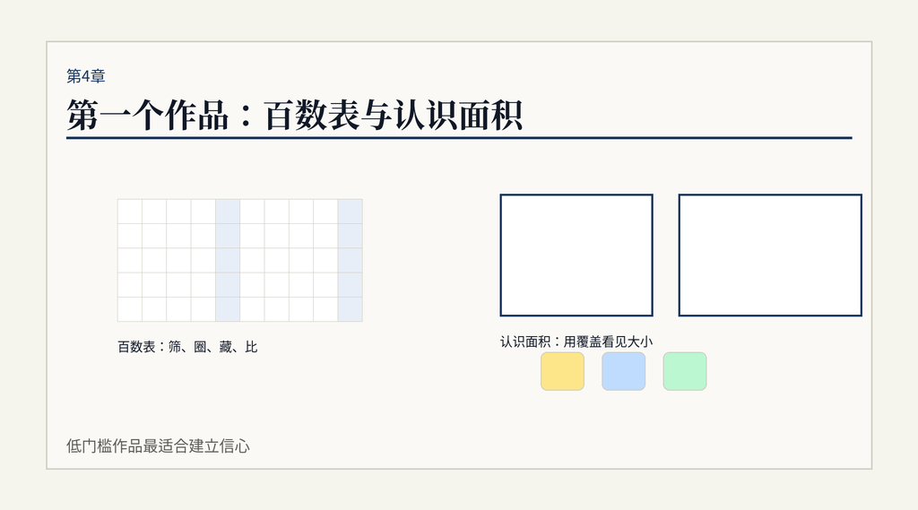

图 4.1

图 4.1：低门槛作品最适合建立信心

### 4.1 为什么建议从百数表开始

本章目标是完成第一个低风险作品。百数表适合入门，因为它结构规则、画面清楚、数学关系丰富。你可以让学生点击 2 的倍数、3 的倍数，观察重叠；可以隐藏部分数字做猜数；可以给质数换颜色；可以把错误点击保留下来，让学生讨论为什么。

百数表提示词不需要复杂技术。关键是说清楚格子数量、数字范围、点击规则和反馈方式。例如：

```
制作一个 1—100 的百数表互动页面，10 行 10 列。学生点击任意数字可切换高亮。页面提供按钮：显示2的倍数、显示3的倍数、清空、隐藏所有数字、恢复数字。点击后用不同浅色标记，并在右侧用一句话提示观察任务：哪些数同时被两种颜色标记？请保持页面简洁，适合投屏。
```

这个作品的学习价值在于，你会第一次看见“结构清楚”比“技术高级”更重要。十行十列不能错，颜色不能刺眼，按钮要大，投屏要清楚。做完百数表，你就理解了 HTML 课件的基本部件：图形区域、控制按钮、状态变化、观察提示。

### 4.2 再做认识面积：从显示答案走向经历过程

第二个入门作品可以选择“认识面积”。它比百数表多了拖拽，但仍然容易理解。页面上方放两个待比较图形，下方放单位小图形，学生拖动覆盖。系统不急着给答案，而是记录覆盖数量，让学生自己发现哪个面积更大。

这里要特别强调“统一单位”。如果下方小图形大小不一致，学生会误解比较规则；如果拖入后不能对齐网格，课堂会被操作问题干扰；如果页面直接显示“大/小”，学生就少了表达理由的机会。因此，提示词要写明：单位图形大小一致，拖入时自动吸附到网格，覆盖数量实时显示，但结论提示要放在学生操作之后。

> **要注意的地方**：第一个作品不要追求全自动。适当保留学生观察和表达的空间，才能让课件为课堂服务，而不是替代课堂讨论。

**本章练习**：任选百数表或认识面积，写出一版五段式提示词，并给自己设置一个验收标准：“投屏距离三米外能否看清？”检查点：你的提示词中有没有明确写出学生操作后的观察任务？

## 第5章 SVG 与 Canvas 的课堂选择

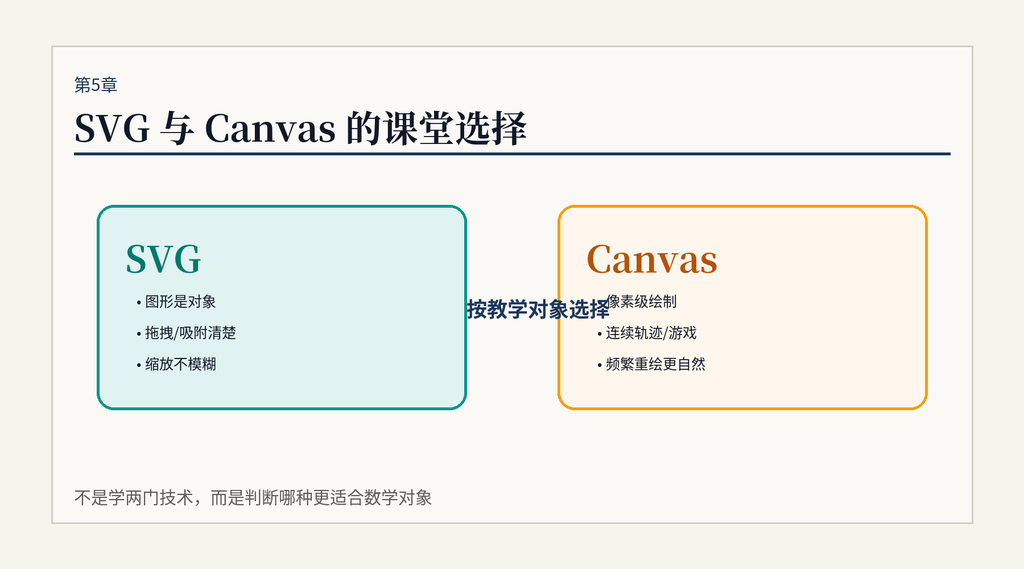

图 5.1

图 5.1：不是学两门技术，而是判断哪种更适合数学对象

### 5.1 用教师语言理解 SVG：每个图形都是可操作对象

本章目标不是让你学习前端技术细节，而是学会在提示词里做技术选择。SVG 可以理解为“每个图形都有名字的矢量黑板”。线段、圆、长方形、点、箭头、文字都是页面中的对象，可以被选中、拖动、改变颜色，也能在放大时保持清晰。

对于小学数学，SVG 特别适合几何对象清楚、需要拖拽吸附、需要投屏放大的场景。例如补墙问题中，每块砖可以作为一个独立对象；两点间距离中，每条路径可以作为线段组合；钟面中，时针分针可以作为可旋转对象；轴对称中，对称轴和图形可以保持清晰边界。

当你希望 AI 使用 SVG，可以在提示词里这样写：“请优先使用 SVG 绘制主要数学图形，图形对象要可拖拽、可吸附、缩放不模糊。”这句话比“做得高级一点”有效得多。

常见误区是以为 SVG 一定比 Canvas 好。不是。SVG 的优势在对象清晰，若对象特别多或需要连续绘制轨迹，也可能变得复杂。

### 5.2 用教师语言理解 Canvas：像一块可以不断重画的画布

Canvas 可以理解为“像素画布”。它适合频繁重绘、轨迹变化、游戏式动画、自由绘制。例如画笔涂色、手势轨迹、密集粒子、连续运动模拟，用 Canvas 往往更自然。若一个课件重点是“看见运动过程”而不是逐个操作对象，Canvas 可能更合适。

以“线段围面”为例，如果学生拖动端点，线段沿轨迹生成曲线并围成面积，页面需要连续记录路径、填充区域、判断闭合，这类动态绘制就可能用 Canvas 或 SVG path 实现。教师不必决定全部代码，但可以说明需求：“需要连续记录拖动轨迹，并在闭合后填充内部区域”。AI 会据此选择实现方式。

一个简单选择表如下：

| 课堂需求 | 更常用选择 | 教师提示语 |
| --- | --- | --- |
| 拖动独立几何图形、自动吸附、投屏清晰 | SVG | 主要图形用 SVG，对象可拖拽，边界清晰 |
| 自由涂画、连续轨迹、大量动画 | Canvas | 使用 Canvas 记录轨迹或持续重绘 |
| 普通按钮、文字、表格、输入框 | HTML/CSS | 使用原生控件，按钮要适合触摸屏 |
| 需要离线分享给同事 | 单文件 HTML | 不依赖外部网络资源，CSS 和 JS 写在同一文件 |

**本章练习**：把“补墙问题”和“掷一掷统计”分别填入上表。检查点：你能否用一句话解释为什么一个更像“拖对象”，另一个更像“记录过程”？

## 第6章 高质量案例拆解矩阵

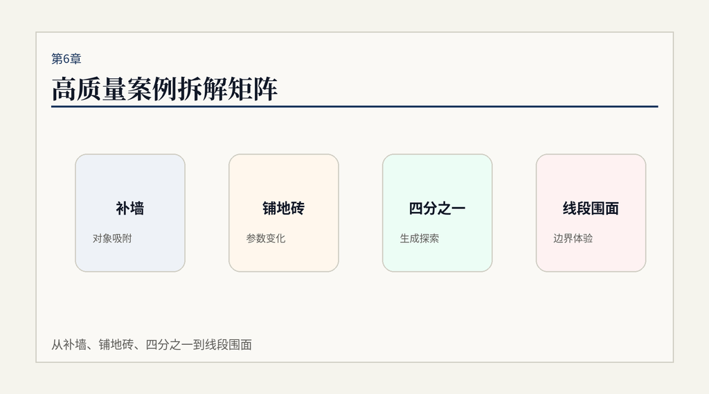

图 6.1

图 6.1：从补墙、铺地砖、四分之一到线段围面

### 6.1 补墙问题：好交互要让错误也有价值

本章目标是学会拆解案例，而不是只收藏成品。补墙问题看似简单：墙上缺砖，学生把砖拖过去补齐。真正的质量点在三个地方：第一，砖块大小必须与缺口一致，否则学生学到的是操作技巧，不是空间匹配；第二，拖动要支持克隆，避免学生把原始砖块拖走后页面混乱；第三，放下时要有吸附和反馈，既能减少操作挫败，又能保留判断过程。

如果用 Canvas 做补墙，画面可能能显示，但每块砖不一定天然是独立对象；如果用 SVG，每块砖可以更清楚地作为可拖动对象。这个案例提醒我们：技术选择要服务教学动作。学生的核心动作是“把一块砖匹配到一个缺口”，所以对象化、吸附、边界反馈很重要。

> **要注意的地方**：低年级课件特别需要容错。手指拖拽不精准、投屏延迟、学生误触都很常见。页面应允许重来，而不是一次错就卡住。

### 6.2 铺地砖、四分之一与线段围面：让学生经历“生成”

铺地砖问题的价值在参数变化。当地面长宽固定，地砖边长变化时，横向块数、纵向块数、总块数会一起变化。好的课件不只是显示结果，而是让学生拖动滑块，看见网格重新划分，再把数量关系说出来。

“四分之一的秘密”更强调生成。学生可以通过复制、旋转、拼摆发现不同图形也能表示四分之一。这里不宜只给标准答案，而要允许多种拼法出现。数学理解往往发生在“原来这样也可以”的瞬间。

线段围面则强调边界体验。定长线段拖动时，学生能感受到长度不变但围成区域变化，这类体验很难靠静态图讲清。页面要把轨迹、闭合、填充、面积变化呈现出来，同时避免操作过复杂。

把这些案例放在一起，可以得到一个高质量矩阵：

| 案例 | 核心数学关系 | 核心交互 | 质量关键 |
| --- | --- | --- | --- |
| 补墙问题 | 形状匹配与空间补全 | 克隆拖拽、自动吸附 | 低年级可操作、错误可恢复 |
| 铺地砖 | 边长变化影响数量 | 滑块调参、实时计算 | 数量变化要可视化 |
| 四分之一 | 等分意义与多样表征 | 复制、旋转、拼摆 | 不急着唯一答案 |
| 线段围面 | 长度不变与面积变化 | 轨迹生成、闭合填充 | 过程要连续、反馈要克制 |

**本章练习**：从你收藏的一个课件中填一行矩阵。检查点：如果你只能保留一个交互，它是否正好对应核心数学关系？

## 第7章 课堂可用的四重验收

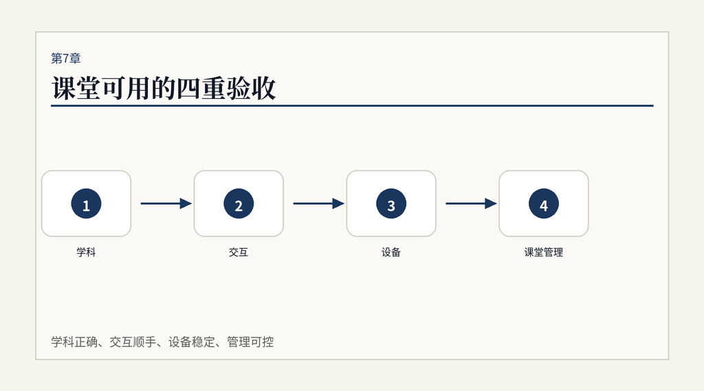

图 7.1

图 7.1：学科正确、交互顺手、设备稳定、管理可控

### 7.1 第一重验收：学科正确比效果惊艳更重要

本章目标是建立验收清单。第一重永远是学科正确。图形比例、数量计算、单位、术语、结论提示都要检查。圆柱和圆锥等底等高时体积关系不能错；钟面大格小格不能混；面积单位覆盖不能大小不一；质数筛选不能把 1 标成质数。

建议每个作品都做“三问”：数学对象是否准确？学生操作是否对应学习目标？页面反馈是否帮助学生解释原因？如果三问有一问答不上来，就先不要上课。

### 7.2 第二到第四重验收：交互、设备与课堂管理

第二重是交互顺手。按钮要足够大，拖拽不应太敏感，触摸屏要能用，重置按钮要明显，关键操作不能藏在角落。低年级页面尤其要减少文字说明，用清楚的图形和颜色引导。

第三重是设备稳定。优先要求单文件 HTML，能离线打开；不要依赖外部图片、外部脚本和网络字体；投屏前用教室电脑或平板试一次；如果要让学生个人设备使用，要检查横屏竖屏、浏览器兼容和加载速度。

第四重是课堂管理。页面是否有“教师控制感”？能否快速清空？能否暂停？学生误操作后能否回到初始状态？如果全班只看投屏，互动节奏应由教师掌控；如果学生分组操作，任务提示要足够短，避免每组都来问“下一步做什么”。

可直接使用这张验收表：

| 维度 | 必查问题 | 不通过时的改法 |
| --- | --- | --- |
| 学科 | 数量、图形、单位、结论是否正确 | 回到教学剧本，删掉干扰功能 |
| 交互 | 鼠标和触摸是否都能完成核心动作 | 加大按钮，增加吸附，加入重置 |
| 设备 | 是否单文件、离线、投屏清楚 | 去掉外链，压缩素材，增大字号 |
| 管理 | 课堂上能否快速开始、暂停、重来 | 增加教师按钮和明确任务提示 |

**本章练习**：用这张表验收你第4章做的作品。检查点：你能否找到至少一个需要修改的细节？如果完全找不到，通常说明验收还不够细。

## 第8章 三周入门路线图

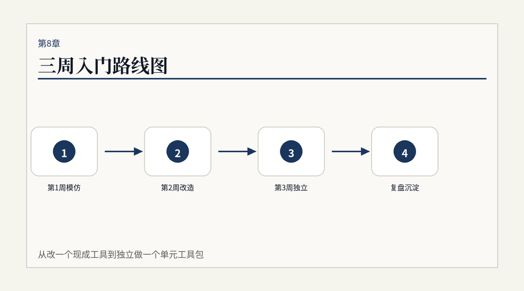

图 8.1

图 8.1：从改一个现成工具到独立做一个单元工具包

### 8.1 第一周：只模仿，不追求原创

本章目标是把学习落到行动。第一周建议只做两件事：复刻一个结构简单的工具，改造一个已有工具。可以从百数表、简单时钟、虚拟钉子板、可打印钟面、抢数游戏中选。复刻时不要急着加入新功能，只练习五段式提示词和验收清单。

每天的任务可以很小：第一天写教学目标，第二天写画面对象，第三天生成初版，第四天修改尺寸和颜色，第五天检查触摸屏，第六天试讲五分钟，第七天写复盘。零基础学习最怕一口吃成专家，小步完成更可靠。

### 8.2 第二周：围绕一个单元做三件小工具

第二周开始围绕一个单元。例如“图形与几何”单元可以做：认识面积、周长比较、铺地砖；“数与代数”单元可以做：百数表、倍数筛选、分数表示；“统计与概率”单元可以做：全班投票、生日统计、掷一掷。

同一单元连续做三件小工具，会让你逐渐形成自己的提示词语言。你会发现，有些要求可以反复使用：全屏自适应、护眼背景、按钮适合触摸、支持重置、关键数据实时显示、不要依赖外部资源。这些就是你的个人课件规范。

### 8.3 第三周：形成自己的“课件开发小手册”

第三周不只是继续做，而是沉淀。把每次成功的提示词、失败的截图、修改前后的差异、课堂使用反馈记录下来。一个教师真正的进步，不是收藏了多少工具，而是知道为什么某个工具在课堂上有效。

建议建立四个文件夹：提示词、成品 HTML、课堂截图、复盘记录。每个作品复盘四句话：解决了哪个教学难点？学生最有效的一个动作是什么？课堂上最卡的一处在哪里？下次要删掉或增强什么？

最后给自己一个自评量表：

| 等级 | 能做到的事 |
| --- | --- |
| 入门 | 能用五段式提示词生成一个可打开的单文件 HTML |
| 稳定 | 能修改尺寸、颜色、提示语、按钮和重置功能 |
| 可用 | 能用四重验收表把课件改到课堂可投屏使用 |
| 熟练 | 能围绕一个单元设计 3—5 个风格一致的小工具 |
| 分享 | 能把提示词、成品和使用建议整理给同备课组教师 |

**最终练习**：选择一个你最熟悉的教学难点，完成“教学剧本—五段式提示词—初版生成—四重验收—课堂复盘”闭环。检查点：你的作品是否让学生多了一次真正的数学思考，而不只是多看了一段动画？

## 延伸阅读与继续学习

- MDN Web Docs：SVG 与 Canvas API，用来理解两类图形技术的基本差异。
- W3C WAI WCAG Quick Reference，用来检查颜色、可读性、键盘与触摸可用性。
- 《义务教育数学课程标准（2022年版）》，用来校准互动课件是否服务数学核心素养。
- 建议继续积累个人案例库：每个案例保存提示词、成品、修改记录和课堂反馈。

真正适合教师的 HTML 学习路线，不是从语法表开始，而是从一节课开始。先把一个难点讲清，再把一个动作做顺，最后把一套方法沉淀下来。等你能稳定地说清“为什么要互动、互动什么、怎样判断有效”，代码就不再是门槛，而会变成你教学设计的一种新表达。